# Seccion_3_Python

### 1. Carga y exploración básica

- Carga el dataset en un DataFrame.
- Muestra los primeros 5 registros.
- Describe brevemente las columnas y sus tipos.
- ¿Hay valores nulos? ¿Cómo los manejarías?

|  | fecha | id_proveedor | proveedor | prod_id | producto | proveedor_unificado | valor_ventas | cantidad_tx |
| --- | --- | --- | --- | --- | --- | --- | --- | --- |
| 0 | 2025-05-26 | 3 | TIGO | 222 | 9.5GB+MIN.ILIM.+20D | TIGO | 5670000 | 252 |
| 1 | 2025-05-27 | 3 | TIGO | 109 | 10 MIN LDI + 2 DIAS | TIGO | 151200 | 28 |
| 2 | 2025-05-28 | 3 | TIGO | 575 | 5 GB+MIN.ILIM+15D | TIGO | 4284000 | 306 |
| 3 | 2025-05-29 | 3 | TIGO | 101 | 5 MIN LDI + 1DIA | TIGO | 58900 | 19 |
| 4 | 2025-05-30 | 3 | TIGO | 485 | 13 GB+MINILI+RDS+30D | TIGO | 15307500 | 471 |

```
<class 'pandas.core.frame.DataFrame'>
RangeIndex: 84 entries, 0 to 83
Data columns (total 8 columns):
 #   Column               Non-Null Count  Dtype
---  ------               --------------  -----
 0   fecha                84 non-null     object
 1   id_proveedor         84 non-null     int64
 2   proveedor            84 non-null     object
 3   prod_id              84 non-null     int64
 4   producto             84 non-null     object
 5   proveedor_unificado  84 non-null     object
 6   valor_ventas         84 non-null     int64
 7   cantidad_tx          84 non-null     int64
dtypes: int64(4), object(4)
memory usage: 5.4+ KB
```

```
fecha                  0
id_proveedor           0
proveedor              0
prod_id                0
producto               0
proveedor_unificado    0
valor_ventas           0
cantidad_tx            0
dtype: int64
```

##### Si tuviera datos nulos en este caso específico, eliminaria el registro, ya que esto podría alterar los análisis y los cálculos a la hora de sacar porcentajes, promedios, etc.

ventas = ventas.dropna()

### 2. Limpieza de datos

- Corrige los tipos de datos si es necesario (por ejemplo, fechas).
- Elimina columnas irrelevantes si aplica.
- Crea una columna nueva calculada, por ejemplo: Ganancia = Ingreso - Costo.

```
<class 'pandas.core.series.Series'>
RangeIndex: 84 entries, 0 to 83
Series name: fecha
Non-Null Count  Dtype
--------------  -----
84 non-null     datetime64[ns]
dtypes: datetime64[ns](1)
memory usage: 804.0 bytes
```

##### Todas las columnas están relacionadas asi que no serían necesario eliminar ninguna.

##### Si fuera necesario eliminar una columna: ventas = ventas.drop(columns=['Columna_a_eliminar'])

|  | fecha | id_proveedor | proveedor | prod_id | producto | proveedor_unificado | valor_ventas | cantidad_tx | valor_unitario |
| --- | --- | --- | --- | --- | --- | --- | --- | --- | --- |
| 0 | 2025-05-26 | 3 | TIGO | 222 | 9.5GB+MIN.ILIM.+20D | TIGO | 5670000.0 | 252 | 22500.0 |

### 3. Análisis exploratorio

- ¿Cuáles son los 5 productos más vendidos por unidades?

```
               producto  cantidad_tx
0     400 MB+MINILIM+3D        57218
1                 CLARO        47968
2  1.4 GB+MINLIM+RDS+6D        42523
3     2 GB_MIN ILIMT+7D        28985
4    3.5 GB+MINILIM-10D        22623
```

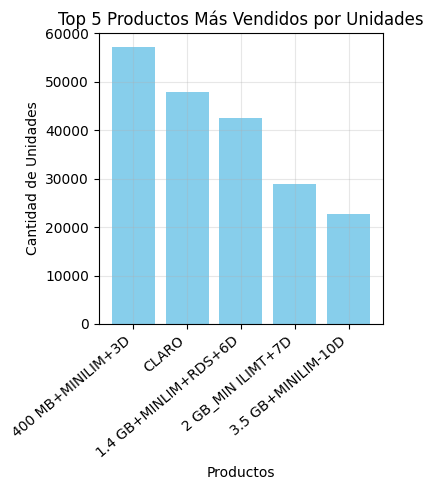

- ¿Cuál es la categoría que más ingresos genera?

```
        proveedor  valor_ventas
0  CLARO PAQUETES  1.542106e+09
```

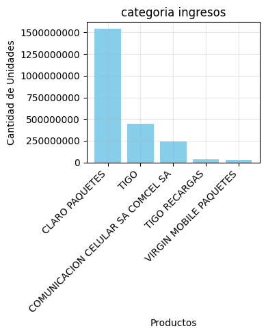

##### La categoria que mas ingresos genera es CLARO PAQUETES con $1,542,106,250 en ventas

- ¿Hay diferencias significativas de ventas por región o canal?

```
  proveedor_unificado  cantidad_tx  porcentaje_cantidad_tx
0               CLARO       242152                   81.01
1                TIGO        53631                   17.94
2              VIRGIN         3135                    1.05
```

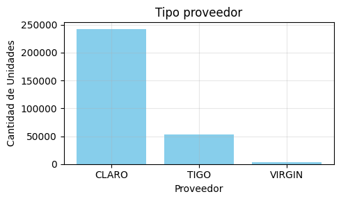

##### CLARO domina el mercadocon (81%), mientras que TIGO (18%) y VIRGIN (1%) tienen ventas considerablemente menores.

### 4. Visualización

- Crea una visualización que muestre la evolución de las ventas mensuales.

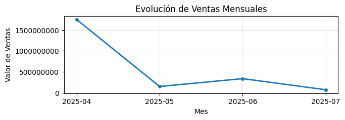

- Muestra un gráfico comparativo entre ingresos y costos por categoría.

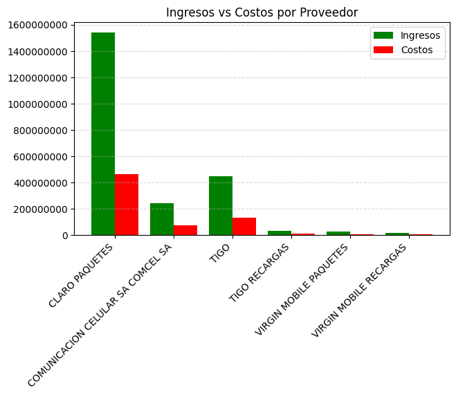

### Debido a que no se tiene la columna de costos tomé un supuesto del 30% por costo de venta para calcularla.

- Usa un gráfico de dispersión (scatter) para mostrar la relación entre el número de ventas y las ganancias.

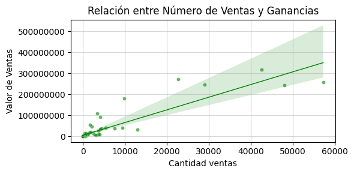

### 5. Insight y comunicación

- En máximo 5 líneas, escribe dos hallazgos interesantes del análisis.
- Propón una acción que el negocio podría tomar basada en esos hallazgos.

#### Hallazgo 1:

CLARO domina completamente el mercado de telecomunicaciones con 242,152 unidades vendidas, representando más del 80% del total de transacciones, mientras que TIGO (53,631) y VIRGIN (3,135) tienen participaciones significativamente menores.

#### Acción recomendada:

El negocio debería enfocar sus esfuerzos comerciales para productos similares al "400 MB+MINILIM+3D". Teniendo en cuenta que el volumen es el factor principal del negocio, tomar un enfoque en aumentar la frecuencia de recompra y recurrencia de clientes. Debido a la fuerte caida en ventas despues del primer mes se debería diseñar estrategias para convertir ventas puntuales en ventas recurrentes.